# Statistics Overview

## Outline

- Randomness
- Summarizing results
- Probability (predicting results)
- Central Limit Theorem
- Inference (interpreting results)
- Study Design

## Randomness

[video not shown]

- Common random-number generators: dice, spinners, cards, coins, tops…
- Discussion: How long will it take to get home?
- Some deterministic systems are treated as random.

## Randomness 2

There are different types of data we can generate.

- Categorical (orderless categories)
  - e.g. Heart, Diamond, Spade, Club
- Ordinal (ordered categories)
  - e.g. Terrible, Bad, Okay, Good, Excellent
- Discrete (usually a few numerical possibilities)
  - e.g. The possible winnings of a scratch-off lottery
  - a standard 6-sided die
- Continuous (numerical with infinite number of possibilities)
  - e.g. The exact direction a spinner stops
  - The exact amount of time a cormorant stays underwater

## Categorical data generation

[video not shown]

## Discrete data generation

[video not shown]

## Continuous data generation

[video not shown]

## Summarizing

- Raw data is overwhelming.

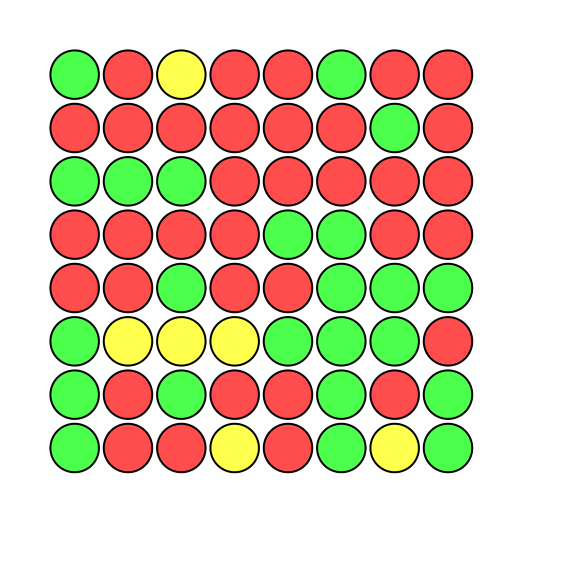

## Summarizing 2, Frequency Table

- So, instead we summarize.

| Color | Frequency | Relative Frequency |
| --- | --- | --- |
| Green | 23 | \(\frac{23}{64}\approx0.3594\) |
| Yellow | 6 | \(\frac{6}{64}\approx0.0938\) |
| Red | 35 | \(\frac{35}{64}\approx0.5469\) |

## Summarizing 3, Bar Chart

- So, instead we summarize. We are visual creatures…

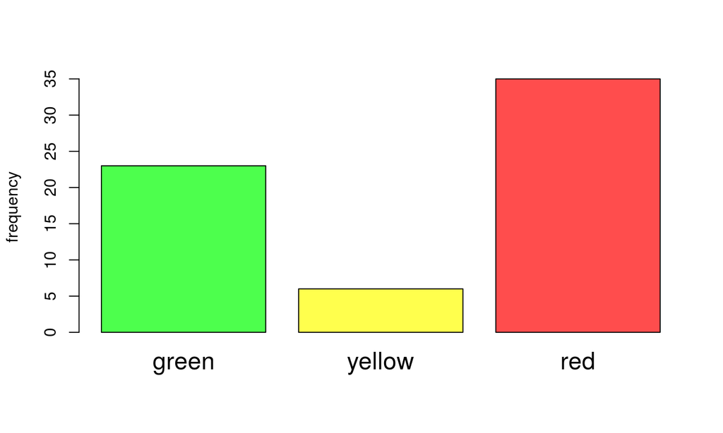

## Probability

A wedge's size determines its long-run relative frequency.

[video not shown]

## Probability 2

Long-run average winnings can be predicted. \[(0.5\times 5) + (0.3\times 15) + (0.2\times 60) = 19\]

[video not shown]

## Central Limit Theorem

If you repeat the previous procedure 1000 times…

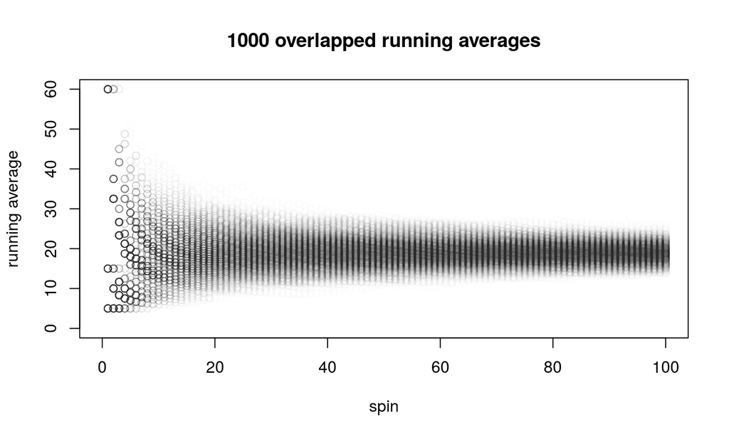

## Central Limit Theorem 2

If you repeat the previous procedure 1000 times…

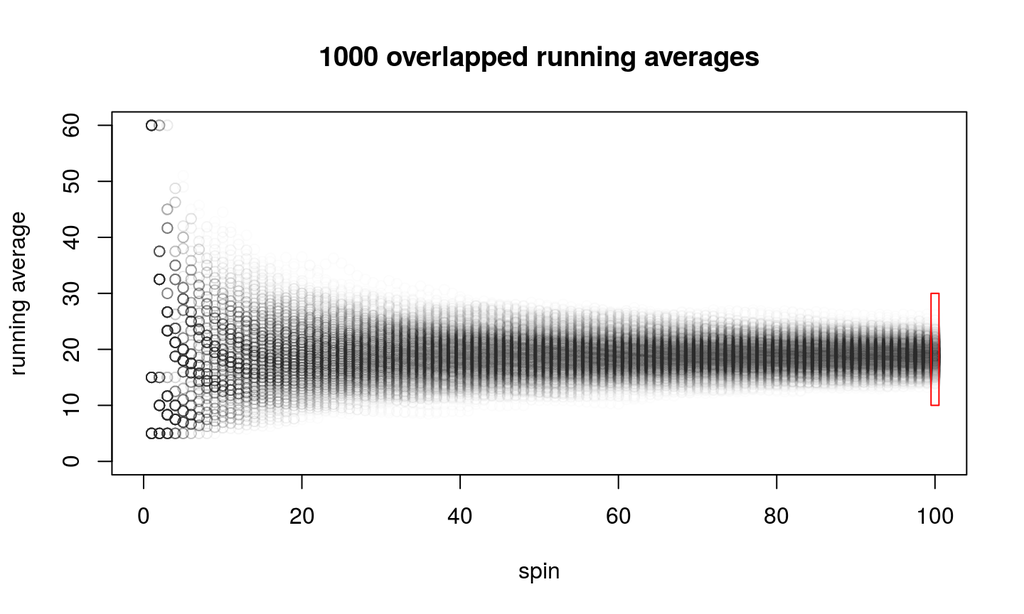

## Resampling gives normal distribution

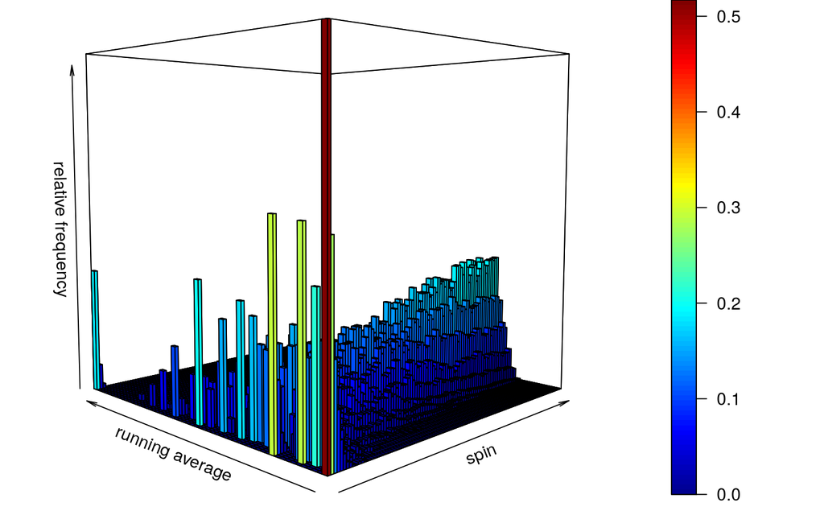

[video not shown]

## Inference

In research, we don't know what the spinner looks like.